# Proyecto final Genómica Humana: Análisis de Mutaciones mendelianas

Alfredo Varela Vega, Elizabeth Márquez Gómez, Joshua Rodríguez Vázquez, Omar Daniel López Olmos

7/06/2021

```r
library(dplyr)
```

```r
library(biomaRt)
library(ggplot2)
library(tidyverse)
library(rentrez)
library(scales)
library(ggrepel)
library(RColorBrewer)
```

### Leer el archivo de [OMIM](https://www.omim.org) que contiene los fenotipos e identificadores de ENSEMBL

```r
# Reading the file
omim_genes<- read.table("data/genemap2.txt", sep = "\t", header= FALSE, fill =TRUE)
# Creating the header
colnames(omim_genes) <- c("chromosome", "genomic_position_start", "genomic_position_end", "cyto_location","computed_cyto_location", "mim_number","gene_symbols","gene_name","approved_symbol","gene_id","ensembl_gene_id","comments","phenotypes","mouse_geneSymbol/ID")

head(omim_genes)
```

|  | chromosome | genomic_position_start | genomic_position_end | cyto_location | computed_cyto_location | mim_number | gene_symbols | gene_name | approved_symbol | gene_id | ensembl_gene_id | comments | phenotypes | mouse_geneSymbol/ID |
| --- | --- | --- | --- | --- | --- | --- | --- | --- | --- | --- | --- | --- | --- | --- |
| 1 | chr1 | 0 | 27600000 | 1p36 |  | 607413 | AD7CNTP | Alzheimer disease neuronal thread protein |  |  |  |  |  |  |
| 2 | chr1 | 0 | 27600000 | 1p36 |  | 612367 | ALPQTL2 | Alkaline phosphatase, plasma level of, QTL 2 |  | 100196914 |  | linkage with rs1780324 | {Alkaline phosphatase, plasma level of, QTL 2}, 612367 (2) |  |
| 3 | chr1 | 0 | 123400000 | 1p |  | 606788 | ANON1 | Anorexia nervosa, susceptibility to, 1 |  | 171514 |  |  | {Anorexia nervosa, susceptibility to, 1}, 606788 (2) |  |
| 4 | chr1 | 0 | 27600000 | 1p36 |  | 605462 | BCC1 | Basal cell carcinoma, susceptibility to, 1 |  | 100307118 |  | associated with rs7538876 | {Basal cell carcinoma, susceptibility to, 1}, 605462 (2) |  |
| 5 | chr1 | 0 | 27600000 | 1p36 |  | 606928 | BMND3 | Bone mineral density QTL 3 |  | 246259 |  | ?another locus at 3p21 | [Bone mineral density QTL 3], 606928 (2) |  |
| 6 | chr1 | 0 | 2300000 | 1p36.33 |  | 618815 | C1DUPp36.33, DUP1p36.33 | Chromosome 1p36.33 duplication syndrome, ATAD3 gene cluster |  |  |  |  | Chromosome 1p36.33 duplication syndrome, ATAD3 gene cluster, 618815 (4), Autosomal dominant |  |

### Filtar enfermedades mendelianas (autosómico dominante, autosómico recesivo, X-linked y Y-linked)

```r
mendelian_omim_genes<- omim_genes %>%
  # Looking for autosomal dominant, autosomal recessive, X-linked dominaant
   filter(grepl("Autosomal|X-linked|Y-linked", phenotypes, ignore.case = TRUE))

# Checking duplicated values from mim id
#head(unique(mendelian_omim_genes$mim_number[duplicated(mendelian_omim_genes$mim_number)]))
# Checking duplicated diseases
# head(unique(query_request_3$phenotype_description[duplicated(query_request_3$phenotype_description)]))
head(mendelian_omim_genes)
```

|  | chromosome | genomic_position_start | genomic_position_end | cyto_location | computed_cyto_location | mim_number | gene_symbols | gene_name | approved_symbol | gene_id | ensembl_gene_id | comments | phenotypes | mouse_geneSymbol/ID |
| --- | --- | --- | --- | --- | --- | --- | --- | --- | --- | --- | --- | --- | --- | --- |
| 1 | chr1 | 0 | 2300000 | 1p36.33 |  | 618815 | C1DUPp36.33, DUP1p36.33 | Chromosome 1p36.33 duplication syndrome, ATAD3 gene cluster |  |  |  |  | Chromosome 1p36.33 duplication syndrome, ATAD3 gene cluster, 618815 (4), Autosomal dominant |  |
| 2 | chr1 | 0 | 27600000 | 1p36 |  | 155600 | CMM, MLM, DNS | Cutaneous malignant melanoma/dysplastic nevus |  | 1243 |  | some linkage studies negative; see 9p | {Melanoma, cutaneous malignant, 1}, 155600 (2), Autosomal dominant |  |
| 3 | chr1 | 0 | 20100000 | 1pter-p36.13 |  | 115665 | CTRCT8, CCV | Cataract, congenital, Volkmann type |  | 7792 |  | linked to Rh in Scottish family | Cataract 8, multiple types, 115665 (2), Autosomal dominant |  |
| 4 | chr1 | 0 | 46300000 | 1p36-p34 |  | 608995 | DYX8 | Dyslexia, susceptibility to, 8 |  | 406874 |  | between D1S552 and D1S1622 | {Dyslexia, susceptibility to, 8}, 608995 (2), Autosomal dominant, Multifactorial |  |
| 5 | chr1 | 0 | 27600000 | 1p36 |  | 610320 | MYP14 | Myopia 14 |  | 100359407 |  | between D1S552 and D1S1622 | Myopia 14, 610320 (2), Autosomal dominant |  |
| 6 | chr1 | 1013496 | 1014539 | 1p36.33 | 1p36.33 | 147571 | ISG15, G1P2, IFI15, IMD38 | ISG15 ubiquitin-like modifier | ISG15 | 9636 | ENSG00000187608 |  | Immunodeficiency 38, 616126 (3), Autosomal recessive | Isg15 (MGI:1855694) |

### Búsqueda en biomart de ENSEMBL por medio del MIM number para anotar la posición los loci en genoma de [homo sapiens](https://www.ensembl.org/Homo_sapiens/Info/Index)

```r
# conncet to genes database
ensembl <- useEnsembl(biomart = "genes")


#   Check available data sets, hsapiens_gene_ensembl corresponde a Human genes (GRCh38.p13)
datasets <- listDatasets(ensembl)
head(datasets)
```

|  | dataset | description | version |
| --- | --- | --- | --- |
| 1 | abrachyrhynchus_gene_ensembl | Pink-footed goose genes (ASM259213v1) | ASM259213v1 |
| 2 | acalliptera_gene_ensembl | Eastern happy genes (fAstCal1.2) | fAstCal1.2 |
| 3 | acarolinensis_gene_ensembl | Green anole genes (AnoCar2.0v2) | AnoCar2.0v2 |
| 4 | acchrysaetos_gene_ensembl | Golden eagle genes (bAquChr1.2) | bAquChr1.2 |
| 5 | acitrinellus_gene_ensembl | Midas cichlid genes (Midas_v5) | Midas_v5 |
| 6 | amelanoleuca_gene_ensembl | Giant panda genes (ASM200744v2) | ASM200744v2 |

```r
# accesing homo sapines genes
ensembl <- useDataset(dataset = "hsapiens_gene_ensembl", mart = ensembl)

ensembl
```

```
## Object of class 'Mart':
##   Using the ENSEMBL_MART_ENSEMBL BioMart database
##   Using the hsapiens_gene_ensembl dataset
```

```r
# filters to apply to my query
#listFilters(ensembl)
# output attributes i want
#listAttributes(ensembl)

list_Attributes<- as.data.frame(listAttributes(ensembl))

# getting biotypes for all our previous omim genes
query_request_3 <- getBM(attributes=c("ensembl_gene_id","chromosome_name","gene_biotype","mim_gene_accession","phenotype_description"),filters=c("mim_gene_accession"),values=mendelian_omim_genes$mim_number, mart= ensembl)
cat("Obtener los biotipos para los genes obtenidos de OMIM: \n")
```

```
## Obtener los biotipos para los genes obtenidos de OMIM:
```

```r
head(query_request_3)
```

|  | ensembl_gene_id | chromosome_name | gene_biotype | mim_gene_accession | phenotype_description |
| --- | --- | --- | --- | --- | --- |
| 1 | ENSG00000138435 | 2 | protein_coding | 100690 | Lethal multiple pterygium syndrome |
| 2 | ENSG00000138435 | 2 | protein_coding | 100690 | Postsynaptic congenital myasthenic syndromes |
| 3 | ENSG00000138435 | 2 | protein_coding | 100690 | MULTIPLE PTERYGIUM SYNDROME LETHAL TYPE |
| 4 | ENSG00000138435 | 2 | protein_coding | 100690 | MYASTHENIC SYNDROME CONGENITAL 1B FAST-CHANNEL |
| 5 | ENSG00000139352 | 12 | protein_coding | 100790 | Haddad syndrome |
| 6 | ENSG00000139352 | 12 | protein_coding | 100790 | CENTRAL HYPOVENTILATION SYNDROME CONGENITAL |

```r
# Filtering only for correctly annotated chromosomes from 1 to 21, X and Y
query_request<- query_request_3 %>%
  filter(chromosome_name %in% c(1:22)| chromosome_name == c("X")| chromosome_name == c("Y"))
cat("Filtrado por cromosoma: \n")
```

```
## Filtrado por cromosoma:
```

```r
head(query_request)
```

|  | ensembl_gene_id | chromosome_name | gene_biotype | mim_gene_accession | phenotype_description |
| --- | --- | --- | --- | --- | --- |
| 1 | ENSG00000138435 | 2 | protein_coding | 100690 | Lethal multiple pterygium syndrome |
| 2 | ENSG00000138435 | 2 | protein_coding | 100690 | Postsynaptic congenital myasthenic syndromes |
| 3 | ENSG00000138435 | 2 | protein_coding | 100690 | MULTIPLE PTERYGIUM SYNDROME LETHAL TYPE |
| 4 | ENSG00000138435 | 2 | protein_coding | 100690 | MYASTHENIC SYNDROME CONGENITAL 1B FAST-CHANNEL |
| 5 | ENSG00000139352 | 12 | protein_coding | 100790 | Haddad syndrome |
| 6 | ENSG00000139352 | 12 | protein_coding | 100790 | CENTRAL HYPOVENTILATION SYNDROME CONGENITAL |

### Datos non coding

Leyendo los datos de la [base de datos non-coding](https://github.com/Gardner-BinfLab/ncVarDB). [ncVarDB](https://academic.oup.com/database/article/doi/10.1093/database/baaa105/6013764)

```r
non_cod_data<- read.table("data/nc_patho_variants/ncVar_pathogenic.tsv", sep ="\t", header = TRUE)
head(non_cod_data)
```

|  | ID | genome | chr | pos | ref | alt | mut_type | mut_position | x_ref | pmed_ID | phenotype |
| --- | --- | --- | --- | --- | --- | --- | --- | --- | --- | --- | --- |
| 1 | ncVarP_A000001 | hg38 | 1 | 2408451 | C | T | substitution | intronic | dbsnp:rs267608183;clinvarID:6770 | 21031596 | Peroxisome biogenesis disorder 6A;Peroxisome biogenesis disorder 6B |
| 2 | ncVarP_A000002 | hg38 | 1 | 3839606 | A | G | substitution | intronic | dbsnp:rs869025276;clinvarID:221274 | 26477546 | Joubert syndrome 25 |
| 3 | ncVarP_A000003 | hg38 | 1 | 11966985 | A | - | deletion | intronic | dbsnp:rs797044447;clinvarID:14368 | 9450904 | Ehlers-Danlos syndrome; hydroxylysine-deficient |
| 4 | ncVarP_A000004 | hg38 | 1 | 21564217 | G | A | substitution | intronic | dbsnp:rs749544042;clinvarID:13678 | 11745997 | Hypophosphatasia; perinatal lethal |
| 5 | ncVarP_A000005 | hg38 | 1 | 42752536 | C | A | substitution | intronic | dbsnp:rs72659354;clinvarID:1254 | 17277775 | Osteogenesis imperfecta type 8 |
| 6 | ncVarP_A000006 | hg38 | 1 | 42757782 | C | A | substitution | intronic | dbsnp:rs72659351;clinvarID:1253 | 29150909 | Osteogenesis imperfecta type 8 |

### Visualización de los resultados conjuntos de ncVarDB y OMIM

#### 1. Pie de proporciones de biotipos de mutación

```r
# Creating frequency tables and joining theme by rows
ensembl_freq<-as.data.frame(table(query_request$gene_biotype))
non_cod_freq<-as.data.frame(table(non_cod_data$mut_position))
biotype_counts<-rbind(ensembl_freq,non_cod_freq)

biotype_counts
```

| Var1 | Freq |
| --- | --- |
| lncRNA | 6 |
| miRNA | 4 |
| protein_coding | 6776 |
| snRNA | 4 |
| 3utr | 3 |
| 5utr | 28 |
| intergenic | 1 |
| intronic | 109 |

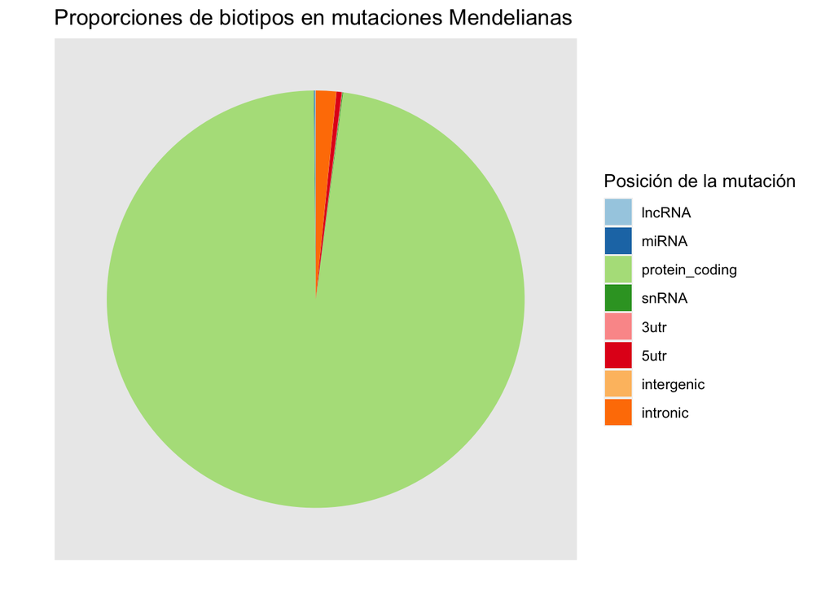

```r
# Biotype Pie chart
#png("./results/mendelian_biotype_pie.png", width = 4, height = 4, units = 'in', res = 300)
ggplot(biotype_counts, aes(x ="", y = Freq, fill = Var1)) +
  geom_bar(stat = "identity") +
  coord_polar("y", start = 0) +
  theme(axis.text = element_blank(),
        axis.ticks = element_blank(),
        panel.grid = element_blank()) +
  labs(title = "Proporciones de biotipos en mutaciones Mendelianas", x= "", y="") +
  scale_fill_brewer(name = "Posición de la mutación", palette = "Paired")
```

```r
#dev.off()
```

#### 2. Gráfica de barras de non-coding

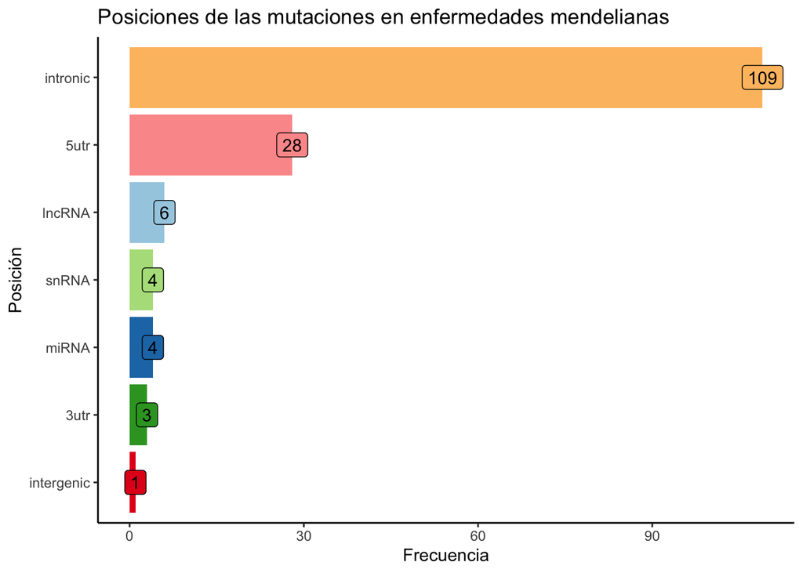

```r
# Using all biotypes but protein coding
biotype_counts_no_prot<-data.frame(biotype= biotype_counts$Var1[biotype_counts$Var1 != "protein_coding"], frequency = biotype_counts$Freq[biotype_counts$Var1 != "protein_coding" ] )

biotype_counts_no_prot<- biotype_counts_no_prot %>%
  arrange(desc(frequency))
# Non coding bar plot
#png("./results/no_prot_mendelian_biotype_bar_plot.png", width = 4, height = 4, units = 'in', res = 300)
ggplot(as.data.frame(biotype_counts_no_prot), aes(x = reorder(biotype,frequency), y = frequency , fill= biotype)) +
  geom_bar(stat = "identity") +
  coord_flip() +
  labs(title = "Posiciones de las mutaciones en enfermedades mendelianas", x= "Posición", y = "Frecuencia") +
  geom_label(label=biotype_counts_no_prot$frequency) +
  scale_fill_brewer(palette = "Paired") +
  theme_classic() +
  theme(legend.position = "none")
```

```r
#dev.off()
```

#### 3. Mutaciones por cromosoma

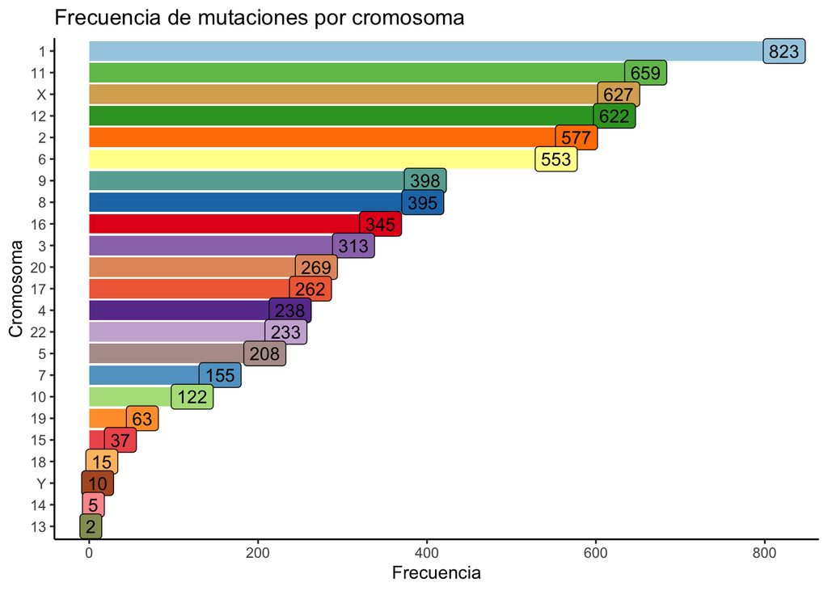

```r
# Creating the chromosome counts data frame
non_cod_chr_count<-as.data.frame(table(non_cod_data$chr))
omim_chr_count<-as.data.frame(table(query_request$chromosome_name))
# Merging the omim and the ncVarDB data frames
chr_merged<-merge(non_cod_chr_count, omim_chr_count, by.x ="Var1", by.y = "Var1", all.x = TRUE, all.y = TRUE)
#Change column names
colnames(chr_merged)<- c("chromosome", "Count_ncVarDB","Count_OMIM")
# Changing Na's for 0
chr_merged[is.na(chr_merged)] <- 0

# Create total count of mutations
chr_merged<- chr_merged %>%
  mutate(total_mutations = Count_ncVarDB + Count_OMIM) %>%
   arrange(desc(total_mutations))

n_colors<- length(chr_merged$chromosome)
mycolors <- colorRampPalette(brewer.pal(12, "Paired"))


#png("./results/mutations_per_chromosome_bar_plot.png", width = 4, height = 4, units = 'in', res = 300)
ggplot(chr_merged, aes(x =reorder(chromosome,total_mutations) , y = total_mutations, fill = chromosome))+
  geom_bar(stat="identity") +
  labs(title="Frecuencia de mutaciones por cromosoma", x= "Cromosoma", y = "Frecuencia") +
  geom_label(label=chr_merged$total_mutations) +
  theme_classic() +
  theme(legend.position = "none") +
  coord_flip() +
  scale_fill_manual(values= mycolors(n_colors))
```

```r
#dev.off
```

#### 4. Por tipo de herencia y sitio codificante o no codificante

El tipo de herencia se extrajo en las mutaciones que lo contenían. Muchas de las mutaciones que caen en sitios no codificantes carecen de la anotación correcta del tipo de herencia. Por ello solo se graficaron los que contenían la anotación correcta de ambas variables. La suma total de observaciones es menor a la de las visualizaciones por localización de la mutación debido a lo anterior.

```r
# Autosomal dominant from ncVarDB
non_cod_auto_dom<- non_cod_data %>%
  filter(grepl("Autosomal dominant", phenotype, ignore.case = TRUE)) %>%
  dplyr::select(phenotype) %>%
  mutate(inheritance = c("autosomal dominant"),
         type = c("non-coding"))
# Autosomal recessive from ncVarDB
non_cod_auto_rec<- non_cod_data %>%
  filter(grepl("Autosomal recessive", phenotype, ignore.case = TRUE)) %>%
  dplyr::select(phenotype) %>%
  mutate(inheritance = c("autosomal recessive"),
         type = c("non-coding"))

# there are no x linked dominants in non_cod_data so only x-linked recessive form ncVarDB neither Y-linked
non_cod_x_rec<- non_cod_data %>%
  filter(grepl("X-linked recessive", phenotype, ignore.case = TRUE)) %>%
  dplyr::select(phenotype) %>%
  mutate(inheritance = c("x-linked recessive"),
         type = c("non-coding"))

# omim autosomal dominant
omim_auto_dom<- mendelian_omim_genes %>%
  filter(grepl("Autosomal dominant", phenotypes, ignore.case = TRUE)) %>%
  dplyr::select(phenotypes) %>%
  mutate(inheritance = c("autosomal dominant"),
         type = c("coding"))
# omim autosomal recessive
omim_auto_rec<- mendelian_omim_genes %>%
  filter(grepl("Autosomal recessive", phenotypes, ignore.case = TRUE)) %>%
  dplyr::select(phenotypes) %>%
  mutate(inheritance = c("autosomal recessive"),
         type = c("coding"))
# omim X-linked dominant
omim_x_linked_dom<- mendelian_omim_genes %>%
  filter(grepl("X-linked dominant", phenotypes, ignore.case = TRUE)) %>%
  dplyr::select(phenotypes) %>%
  mutate(inheritance = c("x-linked dominant"),
         type = c("coding"))
# omim X-linked recessive
omim_x_linked_rec<- mendelian_omim_genes %>%
  filter(grepl("X-linked recessive", phenotypes, ignore.case = TRUE)) %>%
  dplyr::select(phenotypes) %>%
  mutate(inheritance = c("x-linked recessive"),
         type = c("coding"))
# omim Y-linked because no distinction dominant or recessive
omim_y_linked <- mendelian_omim_genes %>%
  filter(grepl("Y-linked", phenotypes, ignore.case = TRUE)) %>%
  dplyr::select(phenotypes) %>%
  mutate(inheritance = c("Y-linked recessive"),
         type = c("coding"))

inheritance_df <- bind_rows(non_cod_auto_dom, non_cod_auto_rec, non_cod_x_rec, omim_auto_dom, omim_auto_rec, omim_x_linked_dom, omim_x_linked_rec, omim_y_linked)
```

```r
# Creating data frame of counts for inheritance
inheritance_counts<- as.data.frame(table(inheritance_df$inheritance))
counts <-as.data.frame(tapply(inheritance_df$inheritance, list(inheritance_df$inheritance, inheritance_df$type), table))

# Adding receptor names columns
counts$inheritance<-rownames(counts)

# Change to long format
counts_long <- reshape(counts,
                       direction = "long",
                       varying = list(names(counts)[1:2]),
                       v.names = "Counts",
                       idvar = "inheritance",
                       timevar = "Status",
                       times=c("coding","non-coding"))


# Replace NA with 0
counts_long[is.na(counts_long)] <- 0
counts_long
```

|  | inheritance | Status | Counts |
| --- | --- | --- | --- |
| autosomal dominant.coding | autosomal dominant | coding | 970 |
| autosomal recessive.coding | autosomal recessive | coding | 1329 |
| x-linked dominant.coding | x-linked dominant | coding | 58 |
| x-linked recessive.coding | x-linked recessive | coding | 138 |
| Y-linked recessive.coding | Y-linked recessive | coding | 7 |
| autosomal dominant.non-coding | autosomal dominant | non-coding | 3 |
| autosomal recessive.non-coding | autosomal recessive | non-coding | 11 |
| x-linked dominant.non-coding | x-linked dominant | non-coding | 0 |
| x-linked recessive.non-coding | x-linked recessive | non-coding | 2 |
| Y-linked recessive.non-coding | Y-linked recessive | non-coding | 0 |

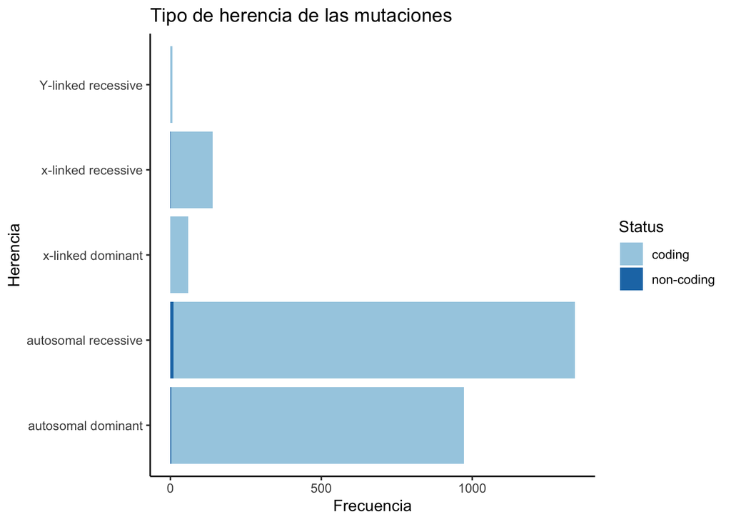

```r
#png("./results/inheritance_bar_plot.png", width = 4, height = 4, units = 'in', res = 300)
ggplot(counts_long, aes(x = inheritance , y = Counts, fill = Status))+
  geom_bar(stat="identity") +
  labs(title="Tipo de herencia de las mutaciones", x= "Herencia", y = "Frecuencia") +
  theme_classic() +
  coord_flip() +
  scale_fill_brewer(palette = "Paired")
```

```r
#dev.off
```